# Banana Quality Prediction

This project develops machine learning models to classify banana quality in supermarket supply chains. The goal is to reduce operational losses by identifying low-quality bananas early using features such as sweetness, acidity, and ripeness. The code covers data preparation, model training, and model evaluation.

# **Step 1: Load and Clean the Data**

Load dataset, standardize target column (quality), and convert to factor for classification

```r
banana <- read.csv("banana_quality.csv")
names(banana)[names(banana) == "Quality"] <- "quality"
banana$quality <- as.factor(banana$quality)
```

Convert quality into a factor (classification labels: good or bad)

```r
banana$quality <- as.factor(banana$quality)
```

# **Step 2: Check the Data**

Inspect data structure, types, and missing values before modeling

Look at the first few rows of the dataset

```r
head(banana)
```

|  | Size | Weight | Sweetness | Softness | HarvestTime | Ripeness | Acidity | quality |
| --- | --- | --- | --- | --- | --- | --- | --- | --- |
| 1 | -1.9249682 | 0.4680781 | 3.0778325 | -1.472177 | 0.2947986 | 2.435570 | 0.2712903 | Good |
| 2 | -2.4097514 | 0.4868699 | 0.3469214 | -2.495099 | -0.8922133 | 2.067549 | 0.3073251 | Good |
| 3 | -0.3576066 | 1.4831762 | 1.5684522 | -2.645145 | -0.6472673 | 3.090643 | 1.4273220 | Good |
| 4 | -0.8685235 | 1.5662014 | 1.8896049 | -1.273761 | -1.0062776 | 1.873001 | 0.4778617 | Good |
| 5 | 0.6518253 | 1.3191992 | -0.0224590 | -1.209709 | -1.4306920 | 1.078345 | 2.8124418 | Good |
| 6 | -2.8077223 | 1.1381357 | 3.4476268 | -1.713302 | -2.2209115 | 2.079410 | 2.2812028 | Good |

Check the structure (shows column types)

```r
str(banana)
```

```
## 'data.frame':    8000 obs. of  8 variables:
##  $ Size       : num  -1.925 -2.41 -0.358 -0.869 0.652 ...
##  $ Weight     : num  0.468 0.487 1.483 1.566 1.319 ...
##  $ Sweetness  : num  3.0778 0.3469 1.5685 1.8896 -0.0225 ...
##  $ Softness   : num  -1.47 -2.5 -2.65 -1.27 -1.21 ...
##  $ HarvestTime: num  0.295 -0.892 -0.647 -1.006 -1.431 ...
##  $ Ripeness   : num  2.44 2.07 3.09 1.87 1.08 ...
##  $ Acidity    : num  0.271 0.307 1.427 0.478 2.812 ...
##  $ quality    : Factor w/ 2 levels "Bad","Good": 2 2 2 2 2 2 2 2 2 2 ...
```

Check for missing values in each column

```r
colSums(is.na(banana))
```

```
##        Size      Weight   Sweetness    Softness HarvestTime    Ripeness
##           0           0           0           0           0           0
##     Acidity     quality
##           0           0
```

Summary statistics (min, max, mean, etc.)

```r
summary(banana)
```

```
##       Size             Weight          Sweetness          Softness
##  Min.   :-7.9981   Min.   :-8.2830   Min.   :-6.4340   Min.   :-6.95932
##  1st Qu.:-2.2777   1st Qu.:-2.2236   1st Qu.:-2.1073   1st Qu.:-1.59046
##  Median :-0.8975   Median :-0.8687   Median :-1.0207   Median : 0.20264
##  Mean   :-0.7478   Mean   :-0.7610   Mean   :-0.7702   Mean   :-0.01444
##  3rd Qu.: 0.6542   3rd Qu.: 0.7755   3rd Qu.: 0.3110   3rd Qu.: 1.54712
##  Max.   : 7.9708   Max.   : 5.6797   Max.   : 7.5394   Max.   : 8.24155
##   HarvestTime         Ripeness          Acidity          quality
##  Min.   :-7.5700   Min.   :-7.4232   Min.   :-8.226977   Bad :3994
##  1st Qu.:-2.1207   1st Qu.:-0.5742   1st Qu.:-1.629450   Good:4006
##  Median :-0.9342   Median : 0.9650   Median : 0.098735
##  Mean   :-0.7513   Mean   : 0.7811   Mean   : 0.008725
##  3rd Qu.: 0.5073   3rd Qu.: 2.2617   3rd Qu.: 1.682063
##  Max.   : 6.2933   Max.   : 7.2490   Max.   : 7.411633
```

# **Step 3: Split the Data**

Split data into training (80%) and test (20%) sets to assess performance on unseen observations.

```r
# Set seed for reproducibility (so we always get the same split)
set.seed(123)
```

```r
# Split the data: 80% for training, 20% for testing
train_index <- createDataPartition(banana$quality, p = 0.8, list = FALSE)
train_data <- banana[train_index, ]
test_data <- banana[-train_index, ]
```

# **Train and Test Data**

Train and evaluate **Logistic Regression, KNN, and Decision Tree models** on the same data for comparison.

# **Model 1: Logistic Regression**

Train LR Model

```r
# Train the logistic regression model
log_model <- glm(quality ~ ., data = train_data, family = "binomial")
```

```r
# View model summary to see feature importance
summary(log_model)
```

```
##
## Call:
## glm(formula = quality ~ ., family = "binomial", data = train_data)
##
## Coefficients:
##             Estimate Std. Error z value Pr(>|z|)
## (Intercept)  1.66719    0.07067  23.591  < 2e-16 ***
## Size         0.66089    0.02823  23.413  < 2e-16 ***
## Weight       0.99112    0.03491  28.388  < 2e-16 ***
## Sweetness    0.78308    0.03101  25.250  < 2e-16 ***
## Softness     0.09294    0.02191   4.242 2.22e-05 ***
## HarvestTime  0.57706    0.02961  19.488  < 2e-16 ***
## Ripeness     0.61632    0.02853  21.605  < 2e-16 ***
## Acidity     -0.09823    0.02211  -4.443 8.88e-06 ***
## ---
## Signif. codes:  0 '***' 0.001 '**' 0.01 '*' 0.05 '.' 0.1 ' ' 1
##
## (Dispersion parameter for binomial family taken to be 1)
##
##     Null deviance: 8873.7  on 6400  degrees of freedom
## Residual deviance: 3693.5  on 6393  degrees of freedom
## AIC: 3709.5
##
## Number of Fisher Scoring iterations: 6
```

All features are statistically significant. Positive coefficients increase the likelihood of “Good” quality, while acidity is negatively associated. The model shows strong fit.

**Evaluate model performance on the test set using a confusion matrix.**

```r
# Make predictions on the test data
log_probs <- predict(log_model, test_data, type = "response")

# Convert probabilities to class labels using 0.5 cutoff
log_preds <- factor(ifelse(log_probs > 0.5, "Good", "Bad"), levels = c("Bad", "Good"))

# Evaluate model performance with a confusion matrix
confusionMatrix(log_preds, test_data$quality)
```

```
## Confusion Matrix and Statistics
##
##           Reference
## Prediction Bad Good
##       Bad  698  104
##       Good 100  697
##
##                Accuracy : 0.8724
##                  95% CI : (0.8551, 0.8884)
##     No Information Rate : 0.5009
##     P-Value [Acc > NIR] : <2e-16
##
##                   Kappa : 0.7448
##
##  Mcnemar's Test P-Value : 0.8336
##
##             Sensitivity : 0.8747
##             Specificity : 0.8702
##          Pos Pred Value : 0.8703
##          Neg Pred Value : 0.8745
##              Prevalence : 0.4991
##          Detection Rate : 0.4365
##    Detection Prevalence : 0.5016
##       Balanced Accuracy : 0.8724
##
##        'Positive' Class : Bad
##
```

The model achieves 87.2% accuracy, with balanced sensitivity and specificity, indicating no strong bias toward either class.

# **Model 2: K-Nearest Neighbors (KNN)**

Scale features and apply KNN to classify banana quality based on nearest neighbors.

```r
# Remove the 'quality' column before scaling the numeric features
train_x <- train_data[, -which(names(train_data) == "quality")]
test_x <- test_data[, -which(names(test_data) == "quality")]

# Scale the training data
train_x_scaled <- scale(train_x)

# Scale the test data using the same parameters as the training set
test_x_scaled <- scale(
  test_x,
  center = attr(train_x_scaled, "scaled:center"),
  scale = attr(train_x_scaled, "scaled:scale")
)

# Extract the labels (target variable)
train_y <- train_data$quality
test_y <- test_data$quality

# Run KNN with k = 5
knn_preds <- knn(train = train_x_scaled, test = test_x_scaled, cl = train_y, k = 5)
```

```r
# Evaluate performance using confusion matrix
confusionMatrix(knn_preds, test_y)
```

```
## Confusion Matrix and Statistics
##
##           Reference
## Prediction Bad Good
##       Bad  786   21
##       Good  12  780
##
##                Accuracy : 0.9794
##                  95% CI : (0.9711, 0.9858)
##     No Information Rate : 0.5009
##     P-Value [Acc > NIR] : <2e-16
##
##                   Kappa : 0.9587
##
##  Mcnemar's Test P-Value : 0.1637
##
##             Sensitivity : 0.9850
##             Specificity : 0.9738
##          Pos Pred Value : 0.9740
##          Neg Pred Value : 0.9848
##              Prevalence : 0.4991
##          Detection Rate : 0.4916
##    Detection Prevalence : 0.5047
##       Balanced Accuracy : 0.9794
##
##        'Positive' Class : Bad
##
```

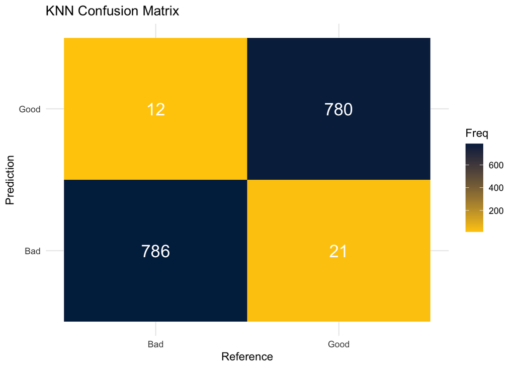

```r
cm <- confusionMatrix(knn_preds, test_y)

cm_df <- as.data.frame(cm$table)

ggplot(cm_df, aes(x = Reference, y = Prediction, fill = Freq)) +
  geom_tile() +
  geom_text(aes(label = Freq), color = "white", size = 6) +
  scale_fill_gradient(low = "#FFCB05", high = "#00274C") +
  theme_minimal() +
  labs(title = "KNN Confusion Matrix")
```

The KNN model achieves 97.9% accuracy, significantly outperforming logistic regression with consistently high sensitivity and specificity.

# **Model 3: Decision Tree**

Train a decision tree to classify banana quality and evaluate an interpretable, rule-based model.

```r
# Train the decision tree model

tree_model <- rpart(quality ~ ., data = train_data, method = "class")

# Make predictions on the test set
tree_preds <- predict(tree_model, test_data, type = "class")
```

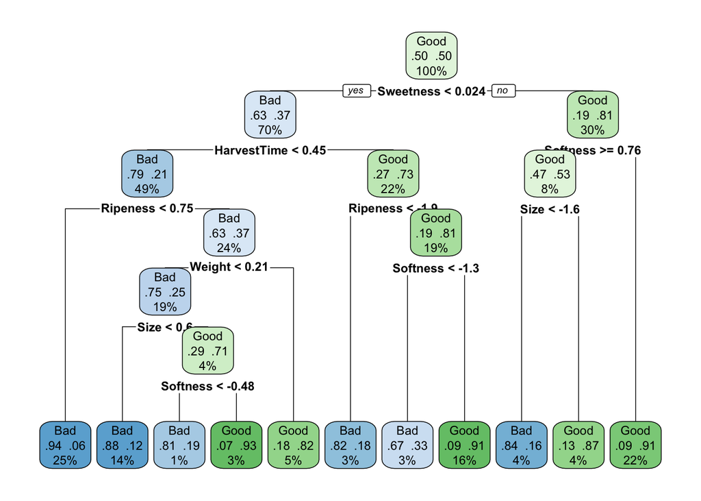

```r
rpart.plot(
  tree_model,
  type = 2,
  extra = 104,
  fallen.leaves = TRUE,
  tweak = 1.2
)
```

The tree uses feature-based splits such as sweetness, ripeness, and harvest time to classify quality through clear, interpretable rules.

```r
# Evaluate the decision tree performance
confusionMatrix(tree_preds, test_data$quality)
```

```
## Confusion Matrix and Statistics
##
##           Reference
## Prediction Bad Good
##       Bad  716  101
##       Good  82  700
##
##                Accuracy : 0.8856
##                  95% CI : (0.8689, 0.9008)
##     No Information Rate : 0.5009
##     P-Value [Acc > NIR] : <2e-16
##
##                   Kappa : 0.7711
##
##  Mcnemar's Test P-Value : 0.1833
##
##             Sensitivity : 0.8972
##             Specificity : 0.8739
##          Pos Pred Value : 0.8764
##          Neg Pred Value : 0.8951
##              Prevalence : 0.4991
##          Detection Rate : 0.4478
##    Detection Prevalence : 0.5109
##       Balanced Accuracy : 0.8856
##
##        'Positive' Class : Bad
##
```

The decision tree achieves 88.6% accuracy, slightly outperforming logistic regression but below KNN. It shows balanced sensitivity (89.7%) and specificity (87.4%) and offers interpretable decision rules.

### Interpretation:

The decision tree model performs well in identifying both good and bad bananas and provides the added benefit of being **easy to interpret**. The model’s decision rules can be visualized and explained to non-technical stakeholders.

While it does not outperform KNN in accuracy, it may be preferred in situations where **model transparency** and **explainability** are important.

# **Model Summary: Key Takeaways**

All models perform well with distinct strengths:

- **Logistic Regression**: Simple, fast baseline with lower accuracy.
- **KNN**: Highest accuracy and best for minimizing prediction errors.
- **Decision Tree**: Balanced performance with strong interpretability.

Overall, KNN is best for accuracy, the decision tree is best for interpretability, and logistic regression is best for speed and simplicity.